# Reproducible Writing

Dynamic APA-formatted manuscripts with `papaja`

Author

Affiliation

Daniela Palleschi

Humboldt-Universität zu Berlin

Published

June 18, 2024

# Learning objectives

Today we will…

- learn about R markdown for writing
- integrate citations with Bib(La)Tex
- learn how to cross-reference
- create lingiustic example sentences

# Resources

- to read more on today’s topic, check out the `papaja` manual (Aust & Barth, 2023)
  - https://frederikaust.com/papaja_man/

## Disclaimer

- this is also a *very* quick-and-dirty introduction on getting started with APA-formatted manuscripts in R markdown
  - there are a *lot* of resources (e.g., E-books, blog posts, forum threads, manuals) that will address specific formatting problems or wishes you may have
  - Google is your friend!
- also, these slides were written in Quarto, and are published as HTML
  - much of the syntax I’m presenting doesn’t actually work in Quarto/HTML
  - but all the raw code that I show will work in R markdown/PDF

# 1 Requirements

- packages:
  - `papaja`
  - `tinytex`
- software (optional)
  - Zotero + a Zotero account
- download from the Moodle or GitHub:
  - `references.bib`

## 1.1 `tinytex`

- includes helper functions for installing LaTeX distribution
  - i.e., helps create PDF outputs

```r
# to install tinytex run these two lines
install.packages("tinytex")
tinytex::install_tinytex()
```

## 1.2 `papaja`

- for APA-formatted scientific manuscripts
  - currently uses APA 6, but we can update it to APA 7

```r
# to install tinytex run these two lines
install.packages("papaja")
```

# 2 Writing

- writing an article or thesis
  - *not* a report
- should be kept separate from the actual analyses
  - e.g., in its own folder or even own project
  - if in its own project: make sure you transfer over files needed (e.g., figures, data, saved models)

## 2.1 Rmarkdown

- we can also write PDFs in Quarto
  - but its relatively new, and there’s more support for scientific articles in R markdown
- most everything in R markdown is identical to Quarto
  - some important differences: code chunk options (we’ll see these later)

## 2.2 APA-formatting with `papaja`

- a package specifically for writing APA-formatted manuscripts
- File > New File > R markdown > From template > APA-formatted article (papaja)
  - will open a file with a long YAML
  - render it and see how it looks

## 2.3 Task

- in a new papaja script, do the following:
1. change the YAML to include your name

# 3 Cross-referencing

- e.g., referring to another section
  - in which case, we need `number_sections: TRUE` in our YAML
- simply provide a label in the same line as a heading, either with `{#section_label}` or `\label{section_label}`
  - then provide the label within `\ref{}`, and the section number will be produced in the output
- the example text below would then be written as *Here is some text in Section 1* (assuming the Introduction is numbered as 1)

```markdown
# Introduction {#section_label}

Here is some text in Section \ref{section_label}.
```

## 3.1 Figures

- or figure, table, example sentence or equation

````markdown
```{r fig-iris, eval = TRUE}
library(ggplot2)
iris |> ggplot() + aes(x = Sepal.Length, y = Sepal.Width) + geom_point()
```
````

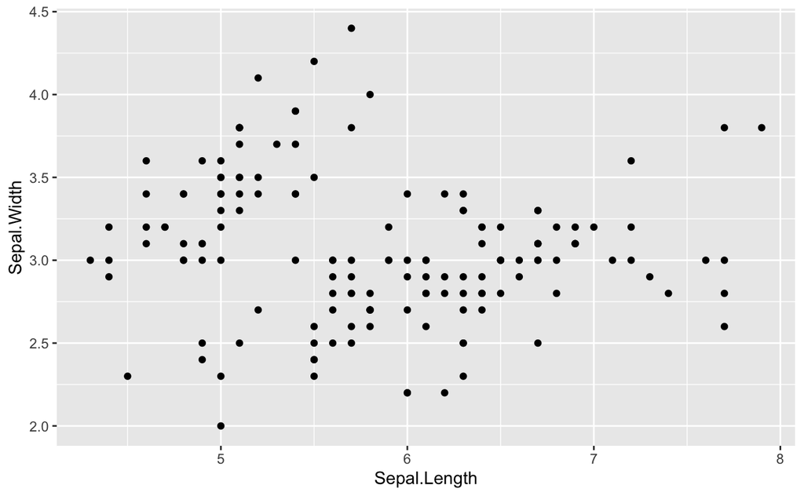

Figure 1

- now if we were to write `As seen in Figure \ref{fig-iris}`, we would get: *As seen in Figure 1*
- be careful not to use underscores (`_`) in your figure labels, this causes problems

## 3.2 Images

- You might also include a figure of the trial procedure, or some other visual description of your data
- For example, in Figure Figure 2 we see an overview of the types of iris (flowers) that make up the data from the built-in `iris` dataset (figure from Mijwil & Abttan, 2021)
- you can then cross-reference to images the same was, by putting the label inside `\ref{}`

````markdown
```{r fig-summary, out.width="100%", fig.pos="t", fig.cap="\\label{fig-summary}Visual depiction of dependent variables from the `iris` dataset"}
knitr::include_graphics(here::here("figures", "iris_photo.png"))
```
````

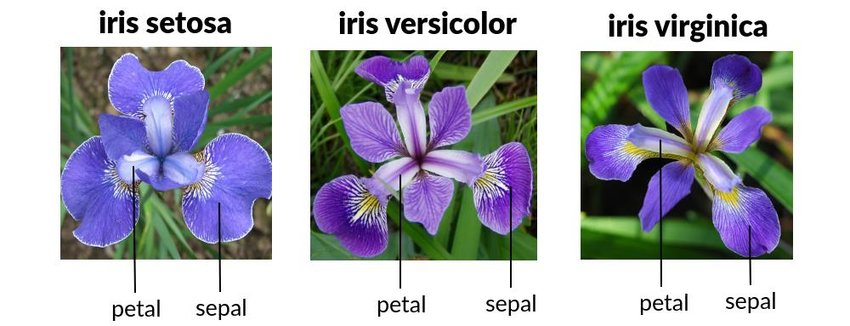

Figure 2: Visual depiction of dependent variables from the `iris` dataset

## 3.3 Example sentences

- we can write example sentences with latex syntax
- first, add this to your YAML

```r
header-includes:
  \usepackage{float} \usepackage{gb4e} \noauthomath
```

- then, you can write an example as follows:

```r
\begin{exe}
\ex \label{ex:example} This is an item with just one example.
\end{exe}
```

1. This is an item with just one example.
- and reference it in your text with `See example \ref{ex:example}`, which will be written as: *See example 1*

# 4 Tables

- e.g., you can give an overview of your stimuli (you could also do this with example sentences)
  - if producing your table with R code, remember to feed it into a function that formats tables
  - e.g., `knitr::kable()` or `papaja::apa_table()`

````markdown
```{r apa-table, eval=F, echo = "fenced"}
library(tidyverse)
tribble(
  ~"Item", ~"Condition", ~"Sentence",
  "1", "a", "Example sentence of condition A",
  "1", "b", "Example sentence of condition B",
  "1", "c", "Example sentence of condition C",
  "1", "d", "Example sentence of condition D",
) |>
  papaja::apa_table(caption = "Example stimuli")
```
````

Table 1: Example stimuli

| Item | Condition | Sentence |
| --- | --- | --- |
| 1 | a | Example sentence of condition A |
| 1 | b | Example sentence of condition B |
| 1 | c | Example sentence of condition C |
| 1 | d | Example sentence of condition D |

### 4.0.1 Table labels

- writing “See `Table apa-table` for example stimuli” will print:
  - *See Table 1 for example stimuli.*
- For this to work, you need to provide a label in the code chunk settings: `{r apa-table, echo=F, eval=T}`. + remember to use `\ref{tab:label}` and replace label with yours (i.e., don’t forget the `tab:` prefix).

## 4.1 Data tables

- You can of course also present tables of your data or models

Table 2: Mean values for `iris` measures

| Species | Sepal.Length | Sepal.Width | Petal.Length | Petal.Width |
| --- | --- | --- | --- | --- |
| setosa | 5.006 | 3.428 | 1.462 | 0.246 |
| versicolor | 5.936 | 2.770 | 4.260 | 1.326 |
| virginica | 6.588 | 2.974 | 5.552 | 2.026 |

- cross-referencing works the same:
  - you write: `Mean values are given in Table \ref{tab:iris-table}.`
  - R markdown prints: *Mean values are given in Table 2.*

## 4.2 Placing tables and figures

- To allow figures and tables to appear in-text (i.e., not at the end of the document), change `floatsintext:` in the YAML to `yes` (it will be `no` by default)
  - otherwise `papaja` pushes all tables and figures to the very end of the document

```r
floatsintext      : yes # CHANGE TO YES to allow figures and tables to float in text
```

# 5 Citations

- the most straightforward way to include citations is by manually adding BibTex citations into your `.bib` file
  - you can define which `.bib` file to use in your YAML (we currently have `bibliography: r-references.bib`)
- you can easily get the BibTex formatted citation via Google Scholar
  - although I suggest using Zotero with the Better BibTex plug in, which stores them locally

## 5.1 BibTex format

- below is an example of a BibTex formatted citation
  - the first info after the opening curly bracked is the reference key (`knuth1984literate`)
- add this reference to your `.bib` file

```r
@article{knuth1984literate,
  title={Literate programming},
  author={Knuth, Donald Ervin},
  journal={The computer journal},
  volume={27},
  number={2},
  pages={97--111},
  year={1984},
  publisher={Oxford University Press}
}
```

### 5.1.1 In-text citations

- to then include a reference in-text, include the BibTeX reference key preceded `@`
- so if we write `@knuth1984literate` we should get a formatted citation: Knuth (1984)
  - and the full citation should be added to our references section
- if we were to write `[@knuth1984literate]` we would get the reference in brackets (Knuth, 1984)
  - to learn more about how to control the formatting of in-text references check out [Section 3.2 (Citations) in the papaja manual](https://frederikaust.com/papaja_man/writing.html#citations)

## 5.2 Zotero

# 6 Output

- PDF: tex file is generated in the process
- `keep_tex: true`
  - will keep the .tex file produced
  - if you want to move the document to Overleaf or LaTeX, I recommend:
1. Add `keep_tex: true` to your YAML
2. Render your document
3. Go find the `.tex` output in the folder
4. Upload this `tex` file to an Overleaf project
5. Make sure to also copy over any figures created in the output

## 6.1 Collaboration

- unfortunately, there’s no elegant method for collaborative writing in R markdown/Rstudio
  - the only real option is to use a remote git repository (e.g., GitHub or GitLab)
  - but this has a steep learning curve and is prone to problems when collaborators aren’t familiar with git
  - track changes are also not as elegant as in Overleaf, Google Docs, Word documents, etc. (e.g., with accept/reject buttons or pop-up comments)
- if you have co-authors, consider they may or may not be R (markdown) or LaTeX or R-savvy
- you could send collaborators a PDF that they annotate and then you make the changes back in your R markdown script(s)
  - but this is quite labour intensive on your side
- alternatively, you can also output your first draft as a Word document and then use that as a starting point for collaborative writing
  - keep in mind that any changes to the analyses will then need to be done in Rmarkdown and imported to the edited Word document
- there is also the `trackdown` package which integrates R markdown scripts with Google Docs
  - but there are obvious data protection/ethical concerns with doing so
- currently, I prefer to move the first draft to Overleaf
  - I can always re-run my analyses, re-write up my results section, and just replace the LaTeX code for that section

# 7 Thesis writing

- there are also ways to write books in R markdown
  - a lot of web-books are written with `bookdown`, see the website for more: https://bookdown.org/
  - I personally prefer Quarto books for web books, for more info: https://quarto.org/docs/books/
- to write your thesis, there’s the `oxforddown` template
  - https://ulyngs.github.io/oxforddown/
- with these options, each chapter is in a self-contained .Rmd script
  - a ‘parent’ document contains the metadata to knit all chapters into a book

# References

Aust, F., & Barth, M. (2023). *papaja: Prepare reproducible APA journal articles with R Markdown*. https://github.com/crsh/papaja

Knuth, D. E. (1984). Literate programming. *The Computer Journal*, *27*(2), 97–111.

Mijwil, M., & Abttan, R. (2021). Utilizing the Genetic Algorithm to Pruning the C4.5 Decision Tree Algorithm. *Asian Journal of Applied Sciences*, *9*, 45–52. https://doi.org/10.24203/ajas.v9i1.6503